# PROJECT-412-DENİZCAN-TAŞDELEN

Denizcan Taşdelen

10 06 2023

```r
library(stringr)
library(editrules)
library(deducorrect)
library(lubridate)
library(assertive)
library(gapminder)
library(statisticaldataanalysis)
library(mice)
library(naniar)
library(stats)
library(missForest)
library(Hmisc)
library(corrplot)
library(tidyr)
library(simputation)
library(datasets)
library(rcompanion)
library(MASS)
library(ggplot2)
library(caret)
library(interactions)
library(nortest)
library(rcompanion)
#library(LambertW)
#library(corPlot)
library(car)
library(glmnet)
library(ggforce)
library(statsExpressions)
library(ggalt)
library(bbplot)
library(leaflet)
library(readxl)
library(tidyverse)
library(dplyr)
library(ggmosaic)
library(epitools)
library(vcd)
library(ltm)
library(pROC)
library(factoextra)
library(pls)
library(hrbrthemes)
library(reshape2)
library(MLmetrics)
library(simputation)
library(datasets)
library(rcompanion)
library(gridExtra)
library(VIM)
library(lavaan)
library(psych)
library(parsnip)
library(rcompanion)
library(LambertW)
#library(corPlot)
library(car)
library(glmnet)
library(ggforce)
library(ggalt)
library(bbplot)
library(leaflet)
library(readxl)
library(dplyr)
library(ggmosaic)
library(epitools)
library(vcd)
library(ltm)
library(segmented)
library(olsrr)
library(bestNormalize)
library("GGally")
library(viridis)
library(Boruta)
library(plspm)
library(gradDescent)
library(rpart)
library(randomForest)
library(xgboost)
library(mlbench)
library(e1071)
library(gbm)
library(iml)
library(naivebayes)
library(rpart.plot)
library(neuralnet)
library(nnet)
library(devtools)
source_url('https://gist.githubusercontent.com/fawda123/7471137/raw/466c1474d0a505ff044412703516c34f1a4684a5/nnet_plot_update.r')
```

Car Price Prediction dataset is taken from Kaggle, which is online dataset supplier website. Dataset contains 11 categorical and 15 numerical variables. “price” is dependent variable determined by different covariates.

```r
car_data <- read.csv("CarPrice_Assignment.csv")

glimpse(car_data)
```

```
## Rows: 205
## Columns: 26
## $ car_ID           <int> 1, 2, 3, 4, 5, 6, 7, 8, 9, 10, 11, 12, 13, 14, 15, 16~
## $ symboling        <int> 3, 3, 1, 2, 2, 2, 1, 1, 1, 0, 2, 0, 0, 0, 1, 0, 0, 0,~
## $ CarName          <chr> "alfa-romero giulia", "alfa-romero stelvio", "alfa-ro~
## $ fueltype         <chr> "gas", "gas", "gas", "gas", "gas", "gas", "gas", "gas~
## $ aspiration       <chr> "std", "std", "std", "std", "std", "std", "std", "std~
## $ doornumber       <chr> "two", "two", "two", "four", "four", "two", "four", "~
## $ carbody          <chr> "convertible", "convertible", "hatchback", "sedan", "~
## $ drivewheel       <chr> "rwd", "rwd", "rwd", "fwd", "4wd", "fwd", "fwd", "fwd~
## $ enginelocation   <chr> "front", "front", "front", "front", "front", "front",~
## $ wheelbase        <dbl> 88.6, 88.6, 94.5, 99.8, 99.4, 99.8, 105.8, 105.8, 105~
## $ carlength        <dbl> 168.8, 168.8, 171.2, 176.6, 176.6, 177.3, 192.7, 192.~
## $ carwidth         <dbl> 64.1, 64.1, 65.5, 66.2, 66.4, 66.3, 71.4, 71.4, 71.4,~
## $ carheight        <dbl> 48.8, 48.8, 52.4, 54.3, 54.3, 53.1, 55.7, 55.7, 55.9,~
## $ curbweight       <int> 2548, 2548, 2823, 2337, 2824, 2507, 2844, 2954, 3086,~
## $ enginetype       <chr> "dohc", "dohc", "ohcv", "ohc", "ohc", "ohc", "ohc", "~
## $ cylindernumber   <chr> "four", "four", "six", "four", "five", "five", "five"~
## $ enginesize       <int> 130, 130, 152, 109, 136, 136, 136, 136, 131, 131, 108~
## $ fuelsystem       <chr> "mpfi", "mpfi", "mpfi", "mpfi", "mpfi", "mpfi", "mpfi~
## $ boreratio        <dbl> 3.47, 3.47, 2.68, 3.19, 3.19, 3.19, 3.19, 3.19, 3.13,~
## $ stroke           <dbl> 2.68, 2.68, 3.47, 3.40, 3.40, 3.40, 3.40, 3.40, 3.40,~
## $ compressionratio <dbl> 9.00, 9.00, 9.00, 10.00, 8.00, 8.50, 8.50, 8.50, 8.30~
## $ horsepower       <int> 111, 111, 154, 102, 115, 110, 110, 110, 140, 160, 101~
## $ peakrpm          <int> 5000, 5000, 5000, 5500, 5500, 5500, 5500, 5500, 5500,~
## $ citympg          <int> 21, 21, 19, 24, 18, 19, 19, 19, 17, 16, 23, 23, 21, 2~
## $ highwaympg       <int> 27, 27, 26, 30, 22, 25, 25, 25, 20, 22, 29, 29, 28, 2~
## $ price            <dbl> 13495.00, 16500.00, 16500.00, 13950.00, 17450.00, 152~
```

```r
dim(car_data)
```

```
## [1] 205  26
```

**DATA CLEANING**

I removed car_ID variable from the dataset.

```r
car_data <- car_data[,!names(car_data) %in% c("car_ID")]
```

Distinct car names are stored in car_names.

```r
car_names <- c("alfa-romero", "audi", "bmw", "buick", "chevrolet", "dodge", "honda", "isuzu",
               "jaguar", "mazda", "mercury", "mitsubishi", "nissan", "peugeot", "plymouth",
               "plymouth", "porsche", "renault", "saab", "subaru", "toyota", "volkswagen", "volvo")
```

Rows of CarName variable are changed with distinct car names in the car_names.

```r
for (i in car_names) {
  index <- which(str_detect(str_to_lower(car_data$CarName), fixed(i))==TRUE)
  car_data$CarName[index] <- i
}
```

There are some wrong typed car names like “maxda” instead of “mazda” and “toyouta” instead of “toyota”. Also some abbreviations are used like “vw” instead “volkswagen”. I corrected all of them.

```r
table(car_data$CarName)
```

```
##
##       alfa-romero              audi               bmw             buick
##                 3                 7                 8                 8
##         chevrolet             dodge             honda             isuzu
##                 3                 9                13                 4
##            jaguar  maxda glc deluxe         maxda rx3             mazda
##                 3                 1                 1                15
##           mercury        mitsubishi            nissan           peugeot
##                 1                13                18                11
##          plymouth porcshce panamera           porsche           renault
##                 7                 1                 4                 2
##              saab            subaru            toyota    toyouta tercel
##                 6                12                31                 1
##  vokswagen rabbit        volkswagen             volvo         vw dasher
##                 1                 9                11                 1
##         vw rabbit
##                 1
```

```r
car_data$CarName <- str_replace(car_data$CarName,"porcshce", "porsche")
car_data$CarName <- str_replace(car_data$CarName,"vokswagen", "volkswagen")
car_data$CarName <- str_replace(car_data$CarName,"vw dasher", "volkswagen")
car_data$CarName <- str_replace(car_data$CarName,"vw rabbit", "volkswagen")
car_data$CarName <- str_replace(car_data$CarName,"maxda", "mazda")
car_data$CarName <- str_replace(car_data$CarName,"toyouta", "toyota")
```

Car names are corrected.

```r
for (i in car_names) {
  index <- which(str_detect(str_to_lower(car_data$CarName), fixed(i))==TRUE)
  car_data$CarName[index] <- i
}
```

I assigned NA values covering 10% of the whole dataset.

```r
set.seed(12)
car_data <- prodNA(car_data, noNA = 0.1)
head(car_data,5)
```

```
##   symboling     CarName fueltype aspiration doornumber     carbody drivewheel
## 1        NA alfa-romero      gas        std        two        <NA>        rwd
## 2         3 alfa-romero      gas        std        two convertible        rwd
## 3        NA alfa-romero      gas        std        two   hatchback        rwd
## 4         2        audi      gas        std       four       sedan        fwd
## 5         2        audi      gas        std       four       sedan       <NA>
##   enginelocation wheelbase carlength carwidth carheight curbweight enginetype
## 1          front        NA     168.8     64.1      48.8       2548       <NA>
## 2          front      88.6     168.8     64.1      48.8         NA       dohc
## 3          front      94.5     171.2     65.5      52.4       2823       <NA>
## 4          front      99.8     176.6     66.2      54.3         NA        ohc
## 5          front      99.4     176.6     66.4      54.3       2824        ohc
##   cylindernumber enginesize fuelsystem boreratio stroke compressionratio
## 1           four        130       mpfi        NA   2.68               NA
## 2           four        130       mpfi        NA   2.68                9
## 3            six        152       mpfi      2.68   3.47                9
## 4           four        109       mpfi      3.19   3.40               10
## 5           five        136       <NA>      3.19   3.40                8
##   horsepower peakrpm citympg highwaympg price
## 1        111      NA      21         27 13495
## 2        111    5000      NA         27 16500
## 3        154    5000      19         26 16500
## 4        102    5500      24         30 13950
## 5        115    5500      18         NA 17450
```

It seems that NA values are “missing completely at random (MCAR)”.

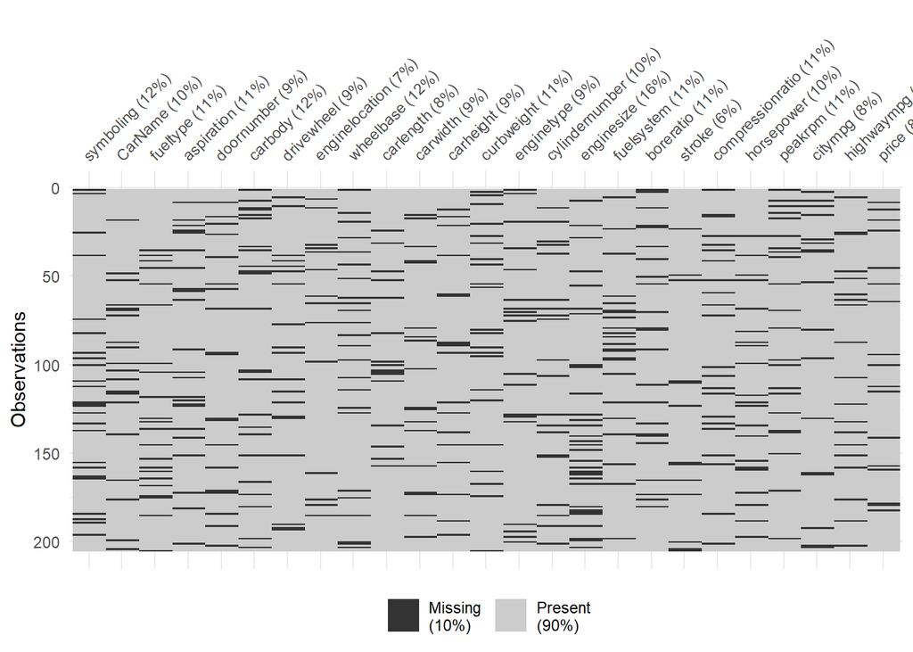

```r
vis_miss(car_data)
```

There are “character” variables which should be “factor”.

```r
glimpse(car_data)
```

```
## Rows: 205
## Columns: 25
## $ symboling        <int> NA, 3, NA, 2, 2, 2, 1, 1, 1, 0, 2, 0, 0, 0, 1, 0, 0, ~
## $ CarName          <chr> "alfa-romero", "alfa-romero", "alfa-romero", "audi", ~
## $ fueltype         <chr> "gas", "gas", "gas", "gas", "gas", "gas", "gas", "gas~
## $ aspiration       <chr> "std", "std", "std", "std", "std", "std", "std", NA, ~
## $ doornumber       <chr> "two", "two", "two", "four", "four", "two", "four", N~
## $ carbody          <chr> NA, "convertible", "hatchback", "sedan", "sedan", "se~
## $ drivewheel       <chr> "rwd", "rwd", "rwd", "fwd", NA, "fwd", "fwd", "fwd", ~
## $ enginelocation   <chr> "front", "front", "front", "front", "front", NA, "fro~
## $ wheelbase        <dbl> NA, 88.6, 94.5, 99.8, 99.4, 99.8, 105.8, 105.8, 105.8~
## $ carlength        <dbl> 168.8, 168.8, 171.2, 176.6, 176.6, 177.3, 192.7, 192.~
## $ carwidth         <dbl> 64.1, 64.1, 65.5, 66.2, 66.4, 66.3, 71.4, 71.4, 71.4,~
## $ carheight        <dbl> 48.8, 48.8, 52.4, 54.3, 54.3, 53.1, 55.7, 55.7, 55.9,~
## $ curbweight       <int> 2548, NA, 2823, NA, 2824, 2507, 2844, 2954, NA, 3053,~
## $ enginetype       <chr> NA, "dohc", NA, "ohc", "ohc", "ohc", "ohc", "ohc", "o~
## $ cylindernumber   <chr> "four", "four", "six", "four", "five", "five", "five"~
## $ enginesize       <int> 130, 130, 152, 109, 136, 136, NA, 136, 131, 131, 108,~
## $ fuelsystem       <chr> "mpfi", "mpfi", "mpfi", "mpfi", NA, "mpfi", "mpfi", "~
## $ boreratio        <dbl> NA, NA, 2.68, 3.19, 3.19, 3.19, 3.19, 3.19, 3.13, 3.1~
## $ stroke           <dbl> 2.68, 2.68, 3.47, 3.40, 3.40, 3.40, 3.40, 3.40, 3.40,~
## $ compressionratio <dbl> NA, 9.00, 9.00, 10.00, 8.00, 8.50, 8.50, 8.50, 8.30, ~
## $ horsepower       <int> 111, 111, 154, 102, 115, 110, 110, 110, 140, 160, 101~
## $ peakrpm          <int> NA, 5000, 5000, 5500, 5500, 5500, NA, 5500, 5500, NA,~
## $ citympg          <int> 21, NA, 19, 24, 18, 19, NA, 19, 17, NA, 23, 23, 21, 2~
## $ highwaympg       <int> 27, 27, 26, 30, NA, 25, 25, 25, 20, 22, 29, 29, 28, 2~
## $ price            <dbl> 13495.00, 16500.00, 16500.00, 13950.00, 17450.00, 152~
```

I changed class of “character” variables to “factor”.

```r
c_n <- colnames(car_data)

for (i in c_n) {
  if (class(car_data[[i]])=="character") {
    car_data[[i]] <- as.factor(car_data[[i]])
  }
}

car_data$symboling <- as.factor(car_data$symboling)

glimpse(car_data)
```

```
## Rows: 205
## Columns: 25
## $ symboling        <fct> NA, 3, NA, 2, 2, 2, 1, 1, 1, 0, 2, 0, 0, 0, 1, 0, 0, ~
## $ CarName          <fct> alfa-romero, alfa-romero, alfa-romero, audi, audi, au~
## $ fueltype         <fct> gas, gas, gas, gas, gas, gas, gas, gas, gas, gas, gas~
## $ aspiration       <fct> std, std, std, std, std, std, std, NA, turbo, turbo, ~
## $ doornumber       <fct> two, two, two, four, four, two, four, NA, four, two, ~
## $ carbody          <fct> NA, convertible, hatchback, sedan, sedan, sedan, NA, ~
## $ drivewheel       <fct> rwd, rwd, rwd, fwd, NA, fwd, fwd, fwd, fwd, NA, rwd, ~
## $ enginelocation   <fct> front, front, front, front, front, NA, front, front, ~
## $ wheelbase        <dbl> NA, 88.6, 94.5, 99.8, 99.4, 99.8, 105.8, 105.8, 105.8~
## $ carlength        <dbl> 168.8, 168.8, 171.2, 176.6, 176.6, 177.3, 192.7, 192.~
## $ carwidth         <dbl> 64.1, 64.1, 65.5, 66.2, 66.4, 66.3, 71.4, 71.4, 71.4,~
## $ carheight        <dbl> 48.8, 48.8, 52.4, 54.3, 54.3, 53.1, 55.7, 55.7, 55.9,~
## $ curbweight       <int> 2548, NA, 2823, NA, 2824, 2507, 2844, 2954, NA, 3053,~
## $ enginetype       <fct> NA, dohc, NA, ohc, ohc, ohc, ohc, ohc, ohc, ohc, ohc,~
## $ cylindernumber   <fct> four, four, six, four, five, five, five, five, five, ~
## $ enginesize       <int> 130, 130, 152, 109, 136, 136, NA, 136, 131, 131, 108,~
## $ fuelsystem       <fct> mpfi, mpfi, mpfi, mpfi, NA, mpfi, mpfi, mpfi, mpfi, m~
## $ boreratio        <dbl> NA, NA, 2.68, 3.19, 3.19, 3.19, 3.19, 3.19, 3.13, 3.1~
## $ stroke           <dbl> 2.68, 2.68, 3.47, 3.40, 3.40, 3.40, 3.40, 3.40, 3.40,~
## $ compressionratio <dbl> NA, 9.00, 9.00, 10.00, 8.00, 8.50, 8.50, 8.50, 8.30, ~
## $ horsepower       <int> 111, 111, 154, 102, 115, 110, 110, 110, 140, 160, 101~
## $ peakrpm          <int> NA, 5000, 5000, 5500, 5500, 5500, NA, 5500, 5500, NA,~
## $ citympg          <int> 21, NA, 19, 24, 18, 19, NA, 19, 17, NA, 23, 23, 21, 2~
## $ highwaympg       <int> 27, 27, 26, 30, NA, 25, 25, 25, 20, 22, 29, 29, 28, 2~
## $ price            <dbl> 13495.00, 16500.00, 16500.00, 13950.00, 17450.00, 152~
```

```r
summary(car_data)
```

```
##  symboling       CarName      fueltype   aspiration  doornumber
##  -2  : 3   toyota    : 30   diesel: 17   std  :148   four:104
##  -1  :21   mazda     : 15   gas   :166   turbo: 34   two : 82
##  0   :59   nissan    : 15   NA's  : 22   NA's : 23   NA's: 19
##  1   :46   honda     : 13
##  2   :29   mitsubishi: 12
##  3   :22   (Other)   :100
##  NA's:25   NA's      : 20
##         carbody   drivewheel enginelocation   wheelbase        carlength
##  convertible: 4   4wd :  7   front:188      Min.   : 86.60   Min.   :141.1
##  hardtop    : 7   fwd :109   rear :  3      1st Qu.: 94.50   1st Qu.:166.8
##  hatchback  :63   rwd : 70   NA's : 14      Median : 96.90   Median :173.2
##  sedan      :84   NA's: 19                  Mean   : 98.69   Mean   :174.3
##  wagon      :23                             3rd Qu.:101.20   3rd Qu.:183.1
##  NA's       :24                             Max.   :120.90   Max.   :208.1
##                                             NA's   :24       NA's   :16
##     carwidth       carheight      curbweight     enginetype  cylindernumber
##  Min.   :60.30   Min.   :47.8   Min.   :1488   ohc    :138   eight :  3
##  1st Qu.:64.00   1st Qu.:52.0   1st Qu.:2191   ohcf   : 13   five  : 10
##  Median :65.50   Median :54.1   Median :2465   dohc   : 11   four  :146
##  Mean   :65.93   Mean   :53.7   Mean   :2587   l      : 10   six   : 21
##  3rd Qu.:66.90   3rd Qu.:55.5   3rd Qu.:2964   ohcv   :  9   twelve:  1
##  Max.   :72.30   Max.   :59.8   Max.   :4066   (Other):  5   two   :  4
##  NA's   :18      NA's   :18     NA's   :22     NA's   : 19   NA's  : 20
##    enginesize      fuelsystem   boreratio         stroke      compressionratio
##  Min.   : 61.0   mpfi   :88   Min.   :2.540   Min.   :2.070   Min.   : 7.00
##  1st Qu.: 97.0   2bbl   :55   1st Qu.:3.150   1st Qu.:3.110   1st Qu.: 8.60
##  Median :120.0   idi    :17   Median :3.310   Median :3.290   Median : 9.00
##  Mean   :127.7   1bbl   :10   Mean   :3.332   Mean   :3.253   Mean   :10.23
##  3rd Qu.:146.0   spdi   : 7   3rd Qu.:3.587   3rd Qu.:3.410   3rd Qu.: 9.40
##  Max.   :326.0   (Other): 5   Max.   :3.940   Max.   :4.170   Max.   :23.00
##  NA's   :32      NA's   :23   NA's   :23      NA's   :13      NA's   :22
##    horsepower       peakrpm        citympg        highwaympg        price
##  Min.   : 48.0   Min.   :4150   Min.   :13.00   Min.   :16.00   Min.   : 5118
##  1st Qu.: 71.5   1st Qu.:4800   1st Qu.:19.00   1st Qu.:25.00   1st Qu.: 7785
##  Median : 95.0   Median :5100   Median :24.50   Median :30.00   Median :10270
##  Mean   :105.3   Mean   :5111   Mean   :25.19   Mean   :30.66   Mean   :13296
##  3rd Qu.:120.2   3rd Qu.:5500   3rd Qu.:30.00   3rd Qu.:34.00   3rd Qu.:16501
##  Max.   :288.0   Max.   :6600   Max.   :47.00   Max.   :54.00   Max.   :45400
##  NA's   :21      NA's   :22     NA's   :17      NA's   :19      NA's   :17
```

**MISSING DATA IMPUTATION**

I imputed missing values using mice packages’ “Classification and Regression Trees (CART)” method.

```r
imputed_Data <- mice(car_data, m=1, maxit = 1, method = 'cart', seed = 500)
complete_data<-mice::complete(imputed_Data,1)
```

No missing value anymore.

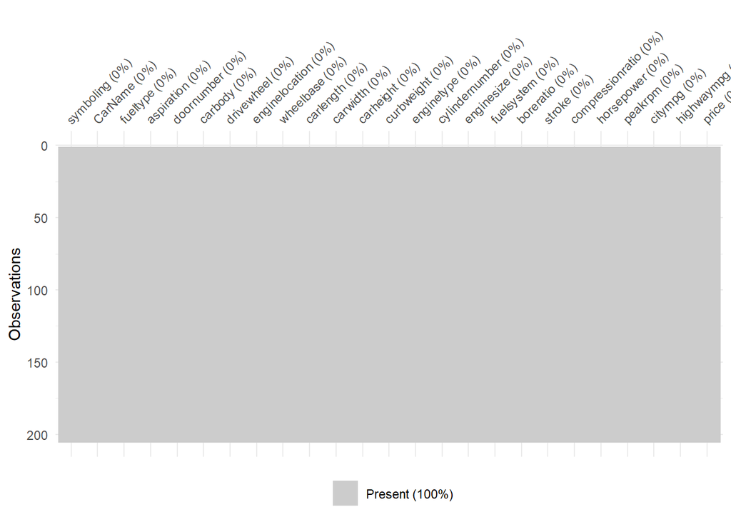

```r
vis_miss(complete_data)
```

There are only 3 cars having “enginelocation” as “rear”.

```r
table(complete_data$enginelocation)
```

```
##
## front  rear
##   202     3
```

So, I removed “enginelocation” variable as well.

```r
complete_data <- complete_data[,!names(complete_data) %in% c("enginelocation")]
```

**FEATURE ENGINEERING**

Symbolling variable in the data set represents the insurance risk of a car. While 3 indicates that the car has high level of insurance risk, 0 and lower integers represent the opposite. Based on symboling, new variable called “risky” was created. It has two levels “yes” and “no” showing the car has risky insurance or not.

```r
complete_data$symboling <- as.numeric(complete_data$symboling) - 3

complete_data$risky <- ifelse(complete_data$symboling > 0, "yes", "no")

complete_data$risky <- as.factor(complete_data$risky)

complete_data <- complete_data %>% select(-symboling)

glimpse(complete_data)
```

```
## Rows: 205
## Columns: 24
## $ CarName          <fct> alfa-romero, alfa-romero, alfa-romero, audi, audi, au~
## $ fueltype         <fct> gas, gas, gas, gas, gas, gas, gas, gas, gas, gas, gas~
## $ aspiration       <fct> std, std, std, std, std, std, std, std, turbo, turbo,~
## $ doornumber       <fct> two, two, two, four, four, two, four, four, four, two~
## $ carbody          <fct> hardtop, convertible, hatchback, sedan, sedan, sedan,~
## $ drivewheel       <fct> rwd, rwd, rwd, fwd, rwd, fwd, fwd, fwd, fwd, rwd, rwd~
## $ wheelbase        <dbl> 89.5, 88.6, 94.5, 99.8, 99.4, 99.8, 105.8, 105.8, 105~
## $ carlength        <dbl> 168.8, 168.8, 171.2, 176.6, 176.6, 177.3, 192.7, 192.~
## $ carwidth         <dbl> 64.1, 64.1, 65.5, 66.2, 66.4, 66.3, 71.4, 71.4, 71.4,~
## $ carheight        <dbl> 48.8, 48.8, 52.4, 54.3, 54.3, 53.1, 55.7, 55.7, 55.9,~
## $ curbweight       <dbl> 2548, 2756, 2823, 2458, 2824, 2507, 2844, 2954, 2579,~
## $ enginetype       <fct> ohc, dohc, ohc, ohc, ohc, ohc, ohc, ohc, ohc, ohc, oh~
## $ cylindernumber   <fct> four, four, six, four, five, five, five, five, five, ~
## $ enginesize       <dbl> 130, 130, 152, 109, 136, 136, 136, 136, 131, 131, 108~
## $ fuelsystem       <fct> mpfi, mpfi, mpfi, mpfi, mpfi, mpfi, mpfi, mpfi, mpfi,~
## $ boreratio        <dbl> 3.62, 3.62, 2.68, 3.19, 3.19, 3.19, 3.19, 3.19, 3.13,~
## $ stroke           <dbl> 2.68, 2.68, 3.47, 3.40, 3.40, 3.40, 3.40, 3.40, 3.40,~
## $ compressionratio <dbl> 9.00, 9.00, 9.00, 10.00, 8.00, 8.50, 8.50, 8.50, 8.30~
## $ horsepower       <dbl> 111, 111, 154, 102, 115, 110, 110, 110, 140, 160, 101~
## $ peakrpm          <dbl> 5000, 5000, 5000, 5500, 5500, 5500, 5500, 5500, 5500,~
## $ citympg          <dbl> 21, 19, 19, 24, 18, 19, 21, 19, 17, 17, 23, 23, 21, 2~
## $ highwaympg       <dbl> 27, 27, 26, 30, 24, 25, 25, 25, 20, 22, 29, 29, 28, 2~
## $ price            <dbl> 13495.00, 16500.00, 16500.00, 13950.00, 17450.00, 152~
## $ risky            <fct> yes, yes, yes, yes, yes, yes, yes, yes, yes, no, yes,~
```

Numerical variables are in numerical_car_data to use in further steps.

```r
numerical_car_col_names <- list()

for (i in colnames(complete_data)) {
  if (class(complete_data[[i]]) != "factor") {
    numerical_car_col_names[i] <- i
  }
}

numerical_car_data <- complete_data[, unlist(numerical_car_col_names)]
```

Lets check whether impuatation is compatible with the remaining points. For example, missing points in the carlength variable are imputed appropriately, since density of carlength variable before and after imputation is pretty coherent.

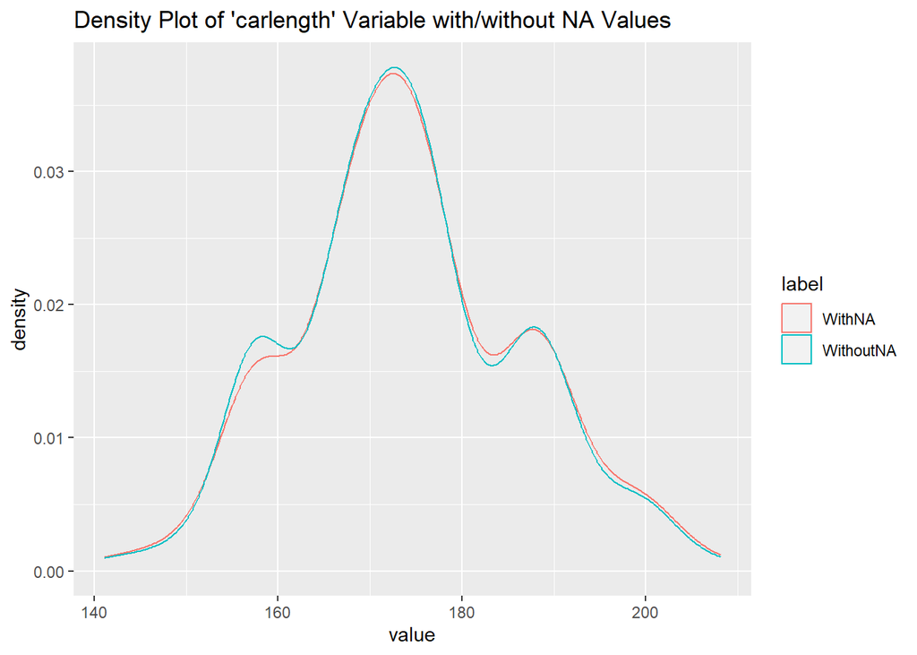

```r
carlength_withNA <- car_data$carlength
carlength_withoutNA <- complete_data$carlength
value<-c(carlength_withNA, carlength_withoutNA)
label <-c(rep("WithNA",length(carlength_withNA)), rep("WithoutNA", length(carlength_withoutNA)))
df_for_plot<-data.frame(value,label)
ggplot(df_for_plot,aes(x=value,colour= label))+geom_density()+ ggtitle("Density Plot of 'carlength' Variable with/without NA Values")
```

Density plots of other numerical variables can be seen below. They are also correctly filled by mice package.

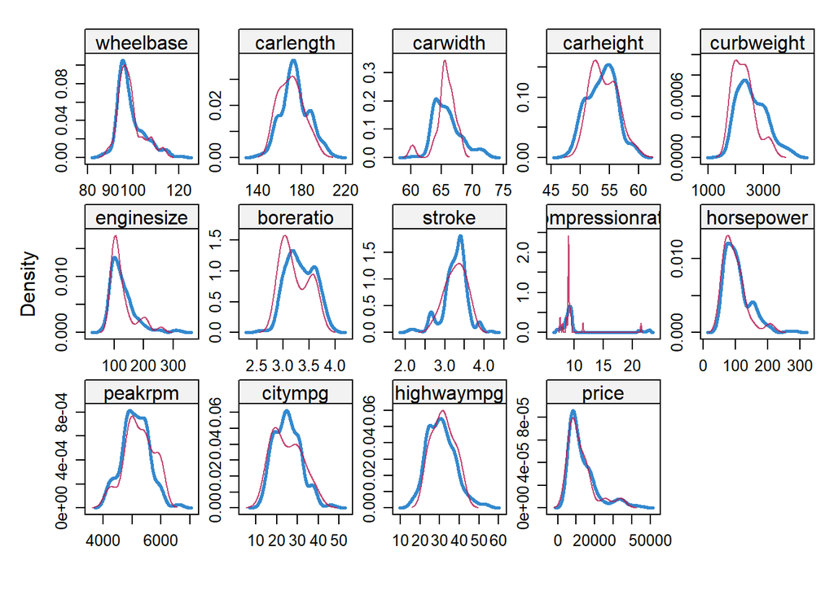

```r
densityplot(imputed_Data)
```

Lets check some pairwise scatter plots to see if missing points are loaded in accordance with existing data points.

```r
nabular_car_data<- bind_shadow(car_data)

nabular_car_data_label<-nabular_car_data%>%add_label_shadow()

complete_data$any_missing<-nabular_car_data_label$any_missing

complete_data$any_missing <- as.factor(complete_data$any_missing)

levels(complete_data$any_missing) <- c("Not Missing", "Missing")

glimpse(complete_data)
```

```
## Rows: 205
## Columns: 25
## $ CarName          <fct> alfa-romero, alfa-romero, alfa-romero, audi, audi, au~
## $ fueltype         <fct> gas, gas, gas, gas, gas, gas, gas, gas, gas, gas, gas~
## $ aspiration       <fct> std, std, std, std, std, std, std, std, turbo, turbo,~
## $ doornumber       <fct> two, two, two, four, four, two, four, four, four, two~
## $ carbody          <fct> hardtop, convertible, hatchback, sedan, sedan, sedan,~
## $ drivewheel       <fct> rwd, rwd, rwd, fwd, rwd, fwd, fwd, fwd, fwd, rwd, rwd~
## $ wheelbase        <dbl> 89.5, 88.6, 94.5, 99.8, 99.4, 99.8, 105.8, 105.8, 105~
## $ carlength        <dbl> 168.8, 168.8, 171.2, 176.6, 176.6, 177.3, 192.7, 192.~
## $ carwidth         <dbl> 64.1, 64.1, 65.5, 66.2, 66.4, 66.3, 71.4, 71.4, 71.4,~
## $ carheight        <dbl> 48.8, 48.8, 52.4, 54.3, 54.3, 53.1, 55.7, 55.7, 55.9,~
## $ curbweight       <dbl> 2548, 2756, 2823, 2458, 2824, 2507, 2844, 2954, 2579,~
## $ enginetype       <fct> ohc, dohc, ohc, ohc, ohc, ohc, ohc, ohc, ohc, ohc, oh~
## $ cylindernumber   <fct> four, four, six, four, five, five, five, five, five, ~
## $ enginesize       <dbl> 130, 130, 152, 109, 136, 136, 136, 136, 131, 131, 108~
## $ fuelsystem       <fct> mpfi, mpfi, mpfi, mpfi, mpfi, mpfi, mpfi, mpfi, mpfi,~
## $ boreratio        <dbl> 3.62, 3.62, 2.68, 3.19, 3.19, 3.19, 3.19, 3.19, 3.13,~
## $ stroke           <dbl> 2.68, 2.68, 3.47, 3.40, 3.40, 3.40, 3.40, 3.40, 3.40,~
## $ compressionratio <dbl> 9.00, 9.00, 9.00, 10.00, 8.00, 8.50, 8.50, 8.50, 8.30~
## $ horsepower       <dbl> 111, 111, 154, 102, 115, 110, 110, 110, 140, 160, 101~
## $ peakrpm          <dbl> 5000, 5000, 5000, 5500, 5500, 5500, 5500, 5500, 5500,~
## $ citympg          <dbl> 21, 19, 19, 24, 18, 19, 21, 19, 17, 17, 23, 23, 21, 2~
## $ highwaympg       <dbl> 27, 27, 26, 30, 24, 25, 25, 25, 20, 22, 29, 29, 28, 2~
## $ price            <dbl> 13495.00, 16500.00, 16500.00, 13950.00, 17450.00, 152~
## $ risky            <fct> yes, yes, yes, yes, yes, yes, yes, yes, yes, no, yes,~
## $ any_missing      <fct> Not Missing, Not Missing, Not Missing, Not Missing, N~
```

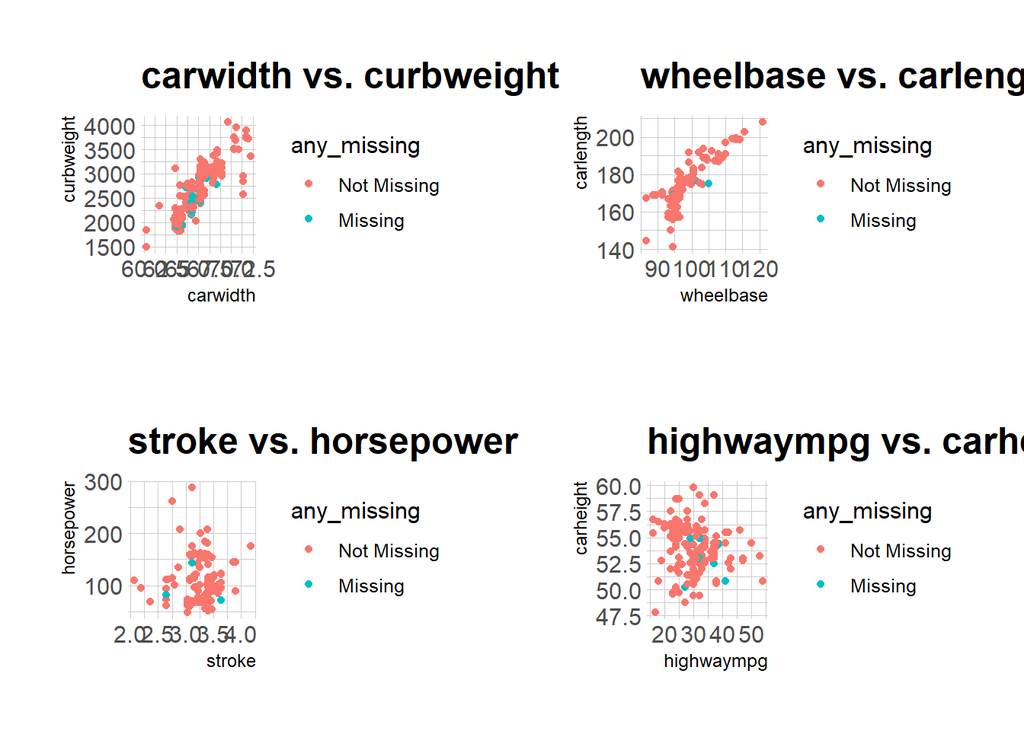

```r
p1 <- ggplot(complete_data,
             aes(x = carwidth,y = curbweight,
                 color = any_missing)) +geom_point()+ ggtitle("carwidth vs. curbweight") +
  theme_ipsum()

p2 <- ggplot(complete_data,
             aes(x = wheelbase,y = carlength,
                 color = any_missing)) +geom_point()+ ggtitle("wheelbase vs. carlength") +
  theme_ipsum()

p3 <- ggplot(complete_data,
             aes(x = stroke,y = horsepower,
                 color = any_missing)) +geom_point()+ ggtitle("stroke vs. horsepower") +
  theme_ipsum()

p4 <- ggplot(complete_data,
             aes(x = highwaympg,y = carheight,
                 color = any_missing)) +geom_point()+ ggtitle("highwaympg vs. carheight")+
  theme_ipsum()

grid.arrange(p1, p2, p3, p4, nrow=2)
```

```r
#"any_missing" variable, used for above scatter plots, was removed.

complete_data <- complete_data[,!names(complete_data) %in% c("any_missing")]
```

**APPLICATION OF DIFFERENT CROSS-VALIDATION TECHNIQUES**

Four different Cross-Validation Methods namely, The Validation Set Approach, LOOCV, K-Fold Cross Validation and Repeated K-Fold Cross Validation, were applied to the dataset and compared based on certain performance measures known as RMSE, Rsquared and MAE.

**1. The Validation set Approach**

Splitting the data into training and test set.

```r
set.seed(2)
training.samples <- complete_data$price %>% createDataPartition(p = 0.8, list = FALSE) #createDataPartition helps you define train set index
train.data  <- complete_data[training.samples, ]
test.data <- complete_data[-training.samples, ]
```

Building the model.

```r
set.seed(546)
model_lm <- lm(price ~., data = train.data)
```

Making prediction

```r
predictions <- model_lm %>% predict(test.data)

info_linear <- data.frame( RMSE = RMSE(predictions, test.data$price),
                           R2 = cor(predictions, test.data$price)^2,
                           MAE = MAE(predictions, test.data$price))

colnames(info_linear) <- c("RMSE", "Rsquared", "MAE")
```

**2. LOOCV**

Defining training control using the following function from caret package.

```r
set.seed(23423)
train.control <- trainControl(method = "LOOCV")
```

Training the model.

```r
set.seed(231)
model_LOOCV <- train(price ~., data = complete_data, method = "lm", trControl = train.control)
summary(model_LOOCV)
```

```
##
## Call:
## lm(formula = .outcome ~ ., data = dat)
##
## Residuals:
##     Min      1Q  Median      3Q     Max
## -4318.2  -930.3     0.0   888.7 10166.4
##
## Coefficients:
##                        Estimate Std. Error t value Pr(>|t|)
## (Intercept)          -4.217e+04  1.597e+04  -2.640  0.00921 **
## CarNameaudi           9.966e+02  2.176e+03   0.458  0.64769
## CarNamebmw            6.774e+03  1.823e+03   3.716  0.00029 ***
## CarNamebuick          3.194e+03  2.265e+03   1.410  0.16080
## CarNamechevrolet     -1.864e+03  2.378e+03  -0.784  0.43440
## CarNamedodge         -2.687e+03  1.874e+03  -1.433  0.15393
## CarNamehonda          2.547e+02  2.256e+03   0.113  0.91027
## CarNameisuzu         -9.067e+02  2.038e+03  -0.445  0.65710
## CarNamejaguar         1.357e+03  2.277e+03   0.596  0.55226
## CarNamemazda         -1.805e+03  1.774e+03  -1.017  0.31067
## CarNamemercury       -3.935e+03  2.825e+03  -1.393  0.16572
## CarNamemitsubishi    -3.207e+03  1.964e+03  -1.633  0.10473
## CarNamenissan        -1.645e+03  1.796e+03  -0.916  0.36133
## CarNamepeugeot        2.057e+03  2.359e+03   0.872  0.38459
## CarNameplymouth      -3.019e+03  1.978e+03  -1.527  0.12906
## CarNameporsche        3.640e+03  2.236e+03   1.628  0.10574
## CarNamerenault       -2.094e+03  2.172e+03  -0.964  0.33675
## CarNamesaab           1.442e+03  1.866e+03   0.773  0.44101
## CarNamesubaru        -9.064e+03  3.617e+03  -2.506  0.01335 *
## CarNametoyota        -2.679e+03  1.583e+03  -1.692  0.09278 .
## CarNamevolkswagen    -1.125e+03  1.785e+03  -0.631  0.52929
## CarNamevolvo         -6.741e+02  1.972e+03  -0.342  0.73295
## fueltypegas           6.809e+02  1.786e+03   0.381  0.70367
## aspirationturbo       1.234e+03  8.517e+02   1.448  0.14972
## doornumbertwo        -6.957e+02  5.772e+02  -1.205  0.23014
## carbodyhardtop       -3.813e+03  1.601e+03  -2.382  0.01856 *
## carbodyhatchback     -4.200e+03  1.437e+03  -2.923  0.00404 **
## carbodysedan         -4.707e+03  1.514e+03  -3.109  0.00227 **
## carbodywagon         -4.100e+03  1.603e+03  -2.557  0.01161 *
## drivewheelfwd        -1.484e+03  1.035e+03  -1.434  0.15381
```

[output cut: 24 more lines]

```
## fuelsystemspfi        6.058e+02  2.810e+03   0.216  0.82965
## boreratio            -7.526e+02  1.360e+03  -0.553  0.58088
## stroke               -1.906e+03  1.108e+03  -1.720  0.08752 .
## compressionratio     -8.885e+01  4.668e+02  -0.190  0.84931
## horsepower            5.020e+01  2.091e+01   2.401  0.01765 *
## peakrpm               4.586e-01  6.910e-01   0.664  0.50803
## citympg              -6.380e+01  1.558e+02  -0.409  0.68289
## highwaympg            1.847e+02  1.260e+02   1.465  0.14505
## riskyyes              1.386e+02  5.298e+02   0.262  0.79397
## ---
## Signif. codes:  0 '***' 0.001 '**' 0.01 '*' 0.05 '.' 0.1 ' ' 1
##
## Residual standard error: 2087 on 142 degrees of freedom
## Multiple R-squared:  0.9525, Adjusted R-squared:  0.9318
## F-statistic: 45.96 on 62 and 142 DF,  p-value: < 2.2e-16
```

Summarizing the results.

```r
print(model_LOOCV)
```

```
## Linear Regression
##
## 205 samples
##  23 predictor
##
## No pre-processing
## Resampling: Leave-One-Out Cross-Validation
## Summary of sample sizes: 204, 204, 204, 204, 204, 204, ...
## Resampling results:
##
##   RMSE      Rsquared   MAE
##   3068.934  0.8610989  2037.377
##
## Tuning parameter 'intercept' was held constant at a value of TRUE
```

```r
result_LOOCV <- model_LOOCV$results[2:4]
result_LOOCV
```

```
##       RMSE  Rsquared      MAE
## 1 3068.934 0.8610989 2037.377
```

**3. K Fold Cross Validation**

Defining training control.

```r
set.seed(2)
train.control <- trainControl(method = "cv", number = 10)
```

Training the model.

```r
set.seed(3289)
model_k_fold_cross_validation <- train(price ~., data = complete_data, method = "lm",
                                       trControl = train.control)
summary(model_k_fold_cross_validation)
```

```
##
## Call:
## lm(formula = .outcome ~ ., data = dat)
##
## Residuals:
##     Min      1Q  Median      3Q     Max
## -4318.2  -930.3     0.0   888.7 10166.4
##
## Coefficients:
##                        Estimate Std. Error t value Pr(>|t|)
## (Intercept)          -4.217e+04  1.597e+04  -2.640  0.00921 **
## CarNameaudi           9.966e+02  2.176e+03   0.458  0.64769
## CarNamebmw            6.774e+03  1.823e+03   3.716  0.00029 ***
## CarNamebuick          3.194e+03  2.265e+03   1.410  0.16080
## CarNamechevrolet     -1.864e+03  2.378e+03  -0.784  0.43440
## CarNamedodge         -2.687e+03  1.874e+03  -1.433  0.15393
## CarNamehonda          2.547e+02  2.256e+03   0.113  0.91027
## CarNameisuzu         -9.067e+02  2.038e+03  -0.445  0.65710
## CarNamejaguar         1.357e+03  2.277e+03   0.596  0.55226
## CarNamemazda         -1.805e+03  1.774e+03  -1.017  0.31067
## CarNamemercury       -3.935e+03  2.825e+03  -1.393  0.16572
## CarNamemitsubishi    -3.207e+03  1.964e+03  -1.633  0.10473
## CarNamenissan        -1.645e+03  1.796e+03  -0.916  0.36133
## CarNamepeugeot        2.057e+03  2.359e+03   0.872  0.38459
## CarNameplymouth      -3.019e+03  1.978e+03  -1.527  0.12906
## CarNameporsche        3.640e+03  2.236e+03   1.628  0.10574
## CarNamerenault       -2.094e+03  2.172e+03  -0.964  0.33675
## CarNamesaab           1.442e+03  1.866e+03   0.773  0.44101
## CarNamesubaru        -9.064e+03  3.617e+03  -2.506  0.01335 *
## CarNametoyota        -2.679e+03  1.583e+03  -1.692  0.09278 .
## CarNamevolkswagen    -1.125e+03  1.785e+03  -0.631  0.52929
## CarNamevolvo         -6.741e+02  1.972e+03  -0.342  0.73295
## fueltypegas           6.809e+02  1.786e+03   0.381  0.70367
## aspirationturbo       1.234e+03  8.517e+02   1.448  0.14972
## doornumbertwo        -6.957e+02  5.772e+02  -1.205  0.23014
## carbodyhardtop       -3.813e+03  1.601e+03  -2.382  0.01856 *
## carbodyhatchback     -4.200e+03  1.437e+03  -2.923  0.00404 **
## carbodysedan         -4.707e+03  1.514e+03  -3.109  0.00227 **
## carbodywagon         -4.100e+03  1.603e+03  -2.557  0.01161 *
## drivewheelfwd        -1.484e+03  1.035e+03  -1.434  0.15381
```

[output cut: 24 more lines]

```
## fuelsystemspfi        6.058e+02  2.810e+03   0.216  0.82965
## boreratio            -7.526e+02  1.360e+03  -0.553  0.58088
## stroke               -1.906e+03  1.108e+03  -1.720  0.08752 .
## compressionratio     -8.885e+01  4.668e+02  -0.190  0.84931
## horsepower            5.020e+01  2.091e+01   2.401  0.01765 *
## peakrpm               4.586e-01  6.910e-01   0.664  0.50803
## citympg              -6.380e+01  1.558e+02  -0.409  0.68289
## highwaympg            1.847e+02  1.260e+02   1.465  0.14505
## riskyyes              1.386e+02  5.298e+02   0.262  0.79397
## ---
## Signif. codes:  0 '***' 0.001 '**' 0.01 '*' 0.05 '.' 0.1 ' ' 1
##
## Residual standard error: 2087 on 142 degrees of freedom
## Multiple R-squared:  0.9525, Adjusted R-squared:  0.9318
## F-statistic: 45.96 on 62 and 142 DF,  p-value: < 2.2e-16
```

Summarizing the results.

```r
print(model_k_fold_cross_validation)
```

```
## Linear Regression
##
## 205 samples
##  23 predictor
##
## No pre-processing
## Resampling: Cross-Validated (10 fold)
## Summary of sample sizes: 184, 185, 185, 184, 185, 185, ...
## Resampling results:
##
##   RMSE      Rsquared   MAE
##   3105.189  0.8793472  2096.686
##
## Tuning parameter 'intercept' was held constant at a value of TRUE
```

```r
result_k_fold_cross_validation <- model_k_fold_cross_validation$results[2:4]
result_k_fold_cross_validation
```

```
##       RMSE  Rsquared      MAE
## 1 3105.189 0.8793472 2096.686
```

**4. Repeated k-fold cross validation**

```r
set.seed(2)
train.control <- trainControl(method = "repeatedcv",
                              number = 10, repeats = 10)
```

Training the model.

```r
set.seed(18734345)
model_Repeated_k_fold <- train(price ~., data = complete_data, method = "lm",
                               trControl = train.control)
summary(model_Repeated_k_fold)
```

```
##
## Call:
## lm(formula = .outcome ~ ., data = dat)
##
## Residuals:
##     Min      1Q  Median      3Q     Max
## -4318.2  -930.3     0.0   888.7 10166.4
##
## Coefficients:
##                        Estimate Std. Error t value Pr(>|t|)
## (Intercept)          -4.217e+04  1.597e+04  -2.640  0.00921 **
## CarNameaudi           9.966e+02  2.176e+03   0.458  0.64769
## CarNamebmw            6.774e+03  1.823e+03   3.716  0.00029 ***
## CarNamebuick          3.194e+03  2.265e+03   1.410  0.16080
## CarNamechevrolet     -1.864e+03  2.378e+03  -0.784  0.43440
## CarNamedodge         -2.687e+03  1.874e+03  -1.433  0.15393
## CarNamehonda          2.547e+02  2.256e+03   0.113  0.91027
## CarNameisuzu         -9.067e+02  2.038e+03  -0.445  0.65710
## CarNamejaguar         1.357e+03  2.277e+03   0.596  0.55226
## CarNamemazda         -1.805e+03  1.774e+03  -1.017  0.31067
## CarNamemercury       -3.935e+03  2.825e+03  -1.393  0.16572
## CarNamemitsubishi    -3.207e+03  1.964e+03  -1.633  0.10473
## CarNamenissan        -1.645e+03  1.796e+03  -0.916  0.36133
## CarNamepeugeot        2.057e+03  2.359e+03   0.872  0.38459
## CarNameplymouth      -3.019e+03  1.978e+03  -1.527  0.12906
## CarNameporsche        3.640e+03  2.236e+03   1.628  0.10574
## CarNamerenault       -2.094e+03  2.172e+03  -0.964  0.33675
## CarNamesaab           1.442e+03  1.866e+03   0.773  0.44101
## CarNamesubaru        -9.064e+03  3.617e+03  -2.506  0.01335 *
## CarNametoyota        -2.679e+03  1.583e+03  -1.692  0.09278 .
## CarNamevolkswagen    -1.125e+03  1.785e+03  -0.631  0.52929
## CarNamevolvo         -6.741e+02  1.972e+03  -0.342  0.73295
## fueltypegas           6.809e+02  1.786e+03   0.381  0.70367
## aspirationturbo       1.234e+03  8.517e+02   1.448  0.14972
## doornumbertwo        -6.957e+02  5.772e+02  -1.205  0.23014
## carbodyhardtop       -3.813e+03  1.601e+03  -2.382  0.01856 *
## carbodyhatchback     -4.200e+03  1.437e+03  -2.923  0.00404 **
## carbodysedan         -4.707e+03  1.514e+03  -3.109  0.00227 **
## carbodywagon         -4.100e+03  1.603e+03  -2.557  0.01161 *
## drivewheelfwd        -1.484e+03  1.035e+03  -1.434  0.15381
```

[output cut: 24 more lines]

```
## fuelsystemspfi        6.058e+02  2.810e+03   0.216  0.82965
## boreratio            -7.526e+02  1.360e+03  -0.553  0.58088
## stroke               -1.906e+03  1.108e+03  -1.720  0.08752 .
## compressionratio     -8.885e+01  4.668e+02  -0.190  0.84931
## horsepower            5.020e+01  2.091e+01   2.401  0.01765 *
## peakrpm               4.586e-01  6.910e-01   0.664  0.50803
## citympg              -6.380e+01  1.558e+02  -0.409  0.68289
## highwaympg            1.847e+02  1.260e+02   1.465  0.14505
## riskyyes              1.386e+02  5.298e+02   0.262  0.79397
## ---
## Signif. codes:  0 '***' 0.001 '**' 0.01 '*' 0.05 '.' 0.1 ' ' 1
##
## Residual standard error: 2087 on 142 degrees of freedom
## Multiple R-squared:  0.9525, Adjusted R-squared:  0.9318
## F-statistic: 45.96 on 62 and 142 DF,  p-value: < 2.2e-16
```

Summarizing the results.

```r
print(model_Repeated_k_fold)
```

```
## Linear Regression
##
## 205 samples
##  23 predictor
##
## No pre-processing
## Resampling: Cross-Validated (10 fold, repeated 10 times)
## Summary of sample sizes: 184, 185, 185, 184, 185, 184, ...
## Resampling results:
##
##   RMSE      Rsquared   MAE
##   3075.681  0.8656182  2101.928
##
## Tuning parameter 'intercept' was held constant at a value of TRUE
```

```r
result_Repeated_k_fold <- model_Repeated_k_fold$results[2:4]
result_Repeated_k_fold
```

```
##       RMSE  Rsquared      MAE
## 1 3075.681 0.8656182 2101.928
```

The Validation Set Approach yields one of the highest R2 value of 88% and lowest RMSE, MAE values of 2249.681 and 1742.834 respectively. Hence, train/test split has done based on The Validation Set Approach.

```r
result <- rbind(info_linear ,  result_LOOCV  ,result_k_fold_cross_validation  , result_Repeated_k_fold)

rownames(result) <- c("Validation_set", "LOOCV", "k_fold_cross_validation", "Repeated_k_fold")

result
```

```
##                             RMSE  Rsquared      MAE
## Validation_set          2249.681 0.8789248 1742.834
## LOOCV                   3068.934 0.8610989 2037.377
## k_fold_cross_validation 3105.189 0.8793472 2096.686
## Repeated_k_fold         3075.681 0.8656182 2101.928
```

**ONE HOT ENCODING**

```r
y <- complete_data$price
complete_data <- complete_data %>% select(-price)
complete_data <- data.frame(y, complete_data)
colnames(complete_data)[1] <- "price"

#define your one hot encoding function
dummy <- dummyVars(" ~ .", data=complete_data)

#perform one-hot encoding on data frame
final_df <- data.frame(predict(dummy, newdata=complete_data))
```

train and test split.

```r
set.seed(2)
training_samples_for_eda <- complete_data$price %>% createDataPartition(p = 0.8, list = FALSE)
train.data_for_eda  <- complete_data[training_samples_for_eda, ]
test.data_for_eda <- complete_data[-training_samples_for_eda, ]

summary(train.data_for_eda)
```

```
##      price             CarName     fueltype   aspiration  doornumber
##  Min.   : 5118   toyota    :28   diesel: 16   std  :140   four:93
##  1st Qu.: 7775   nissan    :16   gas   :149   turbo: 25   two :72
##  Median :10245   mazda     :13
##  Mean   :13525   honda     :11
##  3rd Qu.:16430   volkswagen:10
##  Max.   :45400   peugeot   : 8
##                  (Other)   :79
##         carbody   drivewheel   wheelbase        carlength        carwidth
##  convertible: 3   4wd: 5     Min.   : 86.60   Min.   :141.1   Min.   :60.30
##  hardtop    : 7   fwd:92     1st Qu.: 94.50   1st Qu.:166.8   1st Qu.:64.00
##  hatchback  :55   rwd:68     Median : 96.60   Median :173.2   Median :65.50
##  sedan      :77              Mean   : 98.96   Mean   :174.5   Mean   :65.96
##  wagon      :23              3rd Qu.:101.20   3rd Qu.:183.1   3rd Qu.:66.90
##                              Max.   :120.90   Max.   :208.1   Max.   :72.30
##
##    carheight       curbweight   enginetype  cylindernumber   enginesize
##  Min.   :47.80   Min.   :1488   dohc :  9   eight :  5     Min.   : 61.0
##  1st Qu.:52.00   1st Qu.:2122   dohcv:  1   five  :  8     1st Qu.: 97.0
##  Median :54.10   Median :2455   l    : 11   four  :126     Median :111.0
##  Mean   :53.81   Mean   :2569   ohc  :121   six   : 20     Mean   :129.1
##  3rd Qu.:55.60   3rd Qu.:2975   ohcf :  7   twelve:  1     3rd Qu.:146.0
##  Max.   :59.80   Max.   :4066   ohcv : 10   two   :  5     Max.   :326.0
##                                 rotor:  6
##    fuelsystem   boreratio         stroke      compressionratio   horsepower
##  mpfi   :74   Min.   :2.540   Min.   :2.070   Min.   : 7.00    Min.   : 48.0
##  2bbl   :52   1st Qu.:3.150   1st Qu.:3.110   1st Qu.: 8.70    1st Qu.: 70.0
##  idi    :17   Median :3.270   Median :3.290   Median : 9.00    Median : 95.0
##  1bbl   :10   Mean   :3.314   Mean   :3.257   Mean   :10.26    Mean   :104.7
##  spdi   : 6   3rd Qu.:3.580   3rd Qu.:3.410   3rd Qu.: 9.40    3rd Qu.:116.0
##  4bbl   : 4   Max.   :3.940   Max.   :4.170   Max.   :23.00    Max.   :288.0
##  (Other): 2
##     peakrpm        citympg        highwaympg    risky
##  Min.   :4150   Min.   :13.00   Min.   :16.00   no :71
##  1st Qu.:4800   1st Qu.:19.00   1st Qu.:25.00   yes:94
##  Median :5100   Median :25.00   Median :30.00
##  Mean   :5126   Mean   :25.18   Mean   :30.75
##  3rd Qu.:5500   3rd Qu.:30.00   3rd Qu.:34.00
##  Max.   :6600   Max.   :47.00   Max.   :54.00
##
```

```r
#########################################################################################

set.seed(2)
training.samples <- final_df$price %>% createDataPartition(p = 0.8, list = FALSE)
train.data  <- final_df[training.samples, ]
test.data <- final_df[-training.samples, ]
```

**DATA EXPLORATION**

In the data set, Toyota model of cars have the greatest percentage followed by Nissan, Mazda and so on.

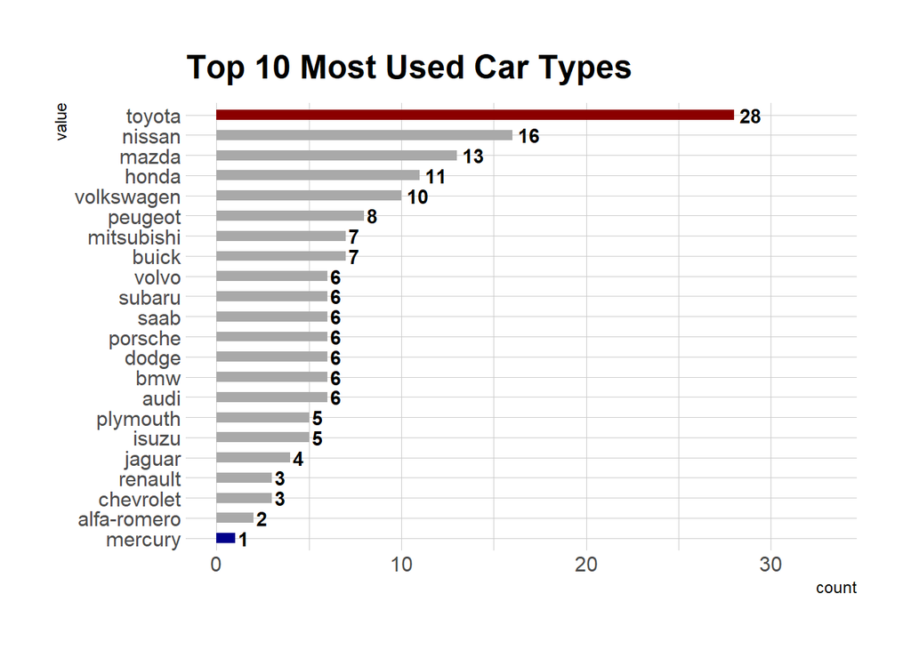

```r
q1 <- sort(table(train.data_for_eda$CarName), decreasing=TRUE)
q1 <- data.frame(q1)
colnames(q1) <- c("value", "count")

value <- q1$value
count <- q1$count

tr <- list()
for (i in 1:length(count)) {
  if(count[i] == max(count)) {
    tr[i] <- "darkred"
  }
  if(count[i] == min(count)) {
    tr[i] <- "darkblue"
  }
  if(count[i] != max(count) & count[i] != min(count)) {
    tr[i] <- "darkgrey"
  }
}

tr <- unlist(tr)

kk <- data.frame(value, count, tr)

newdata <- kk[order(value), ]

tr <- newdata$tr

ggplot(kk,aes(x=reorder(value, count), y=count,
              fill=value))+geom_bar(stat="identity",width=0.5)+ylim(0,max(count)+5)+
  labs(title="Top 10 Most Used Car Types",y="count",x="value")+
  scale_fill_manual(values=tr)+
  geom_text(aes(label=count),hjust=-0.25,fontface="bold")+bbc_style()+coord_flip()+
  theme(plot.title = element_text(size=18),axis.text = element_text(size=12,face="bold"),
        legend.text = element_text(size=10),axis.text.x =
          element_blank(),legend.position='none') +
  theme_ipsum()  + theme(legend.position = "none")
```

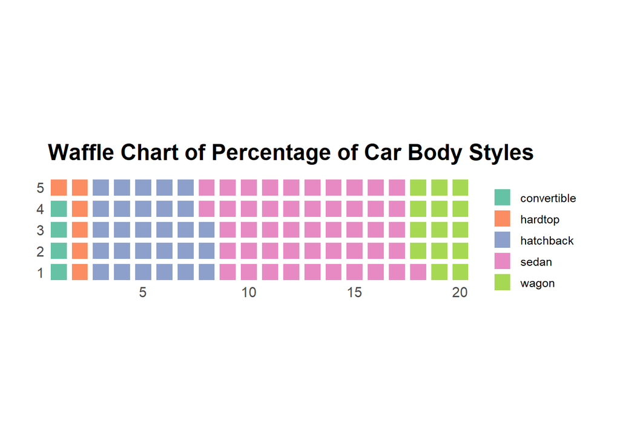

```r
obs_by_carbody <- train.data_for_eda %>% group_by(carbody) %>% summarise(sum_obs=sum(price)) %>% mutate(percent=round(sum_obs/sum(sum_obs)*100))

percent_by_carbody <- obs_by_carbody$percent

names(percent_by_carbody) <- obs_by_carbody$carbody

waffle::waffle(percent_by_carbody, rows=5) + ggtitle("Waffle Chart of Percentage of Car Body Styles") + theme_ipsum()
```

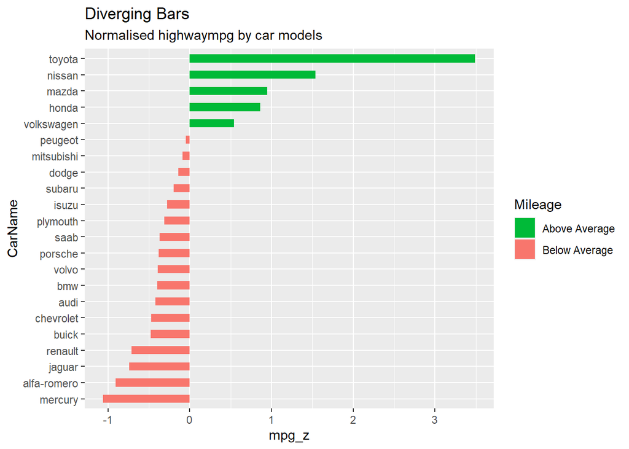

```r
grouped_sum_highwaympg <- train.data_for_eda %>% group_by(CarName) %>% summarise(sum_highwaympg=sum(highwaympg))
grouped_sum_highwaympg <- data.frame(grouped_sum_highwaympg)

grouped_cnt <- train.data_for_eda %>% group_by(CarName, .drop = FALSE) %>% count()
grouped_cnt <- data.frame(grouped_cnt)

data_above_below <- cbind(grouped_sum_highwaympg, grouped_cnt[2])

data_above_below$mpg_z <- round((data_above_below$sum_highwaympg - mean(data_above_below$sum_highwaympg))/sd(data_above_below$sum_highwaympg), 2)  # compute normalized mpg
data_above_below$mpg_type <- ifelse(data_above_below$mpg_z < 0, "below", "above")  # above / below avg flag
data_above_below <- data_above_below[order(data_above_below$mpg_z), ]  # sort
data_above_below$CarName <- factor(data_above_below$CarName, levels = data_above_below$CarName)  # convert to factor to retain sorted order in plot.

# Diverging Barcharts
ggplot(data_above_below, aes(x=CarName, y=mpg_z, label=mpg_z)) +
  geom_bar(stat='identity', aes(fill=mpg_type), width=.5)  +
  scale_fill_manual(name="Mileage",
                    labels = c("Above Average", "Below Average"),
                    values = c("above"="#00ba38", "below"="#f8766d")) +
  labs(subtitle="Normalised highwaympg by car models",
       title= "Diverging Bars") +
  coord_flip()
```

As it is seen from below dot plot, Buick and Porsche model of cars have the highest price and Chevrolet model of cars have the lowest price among all type of cars.

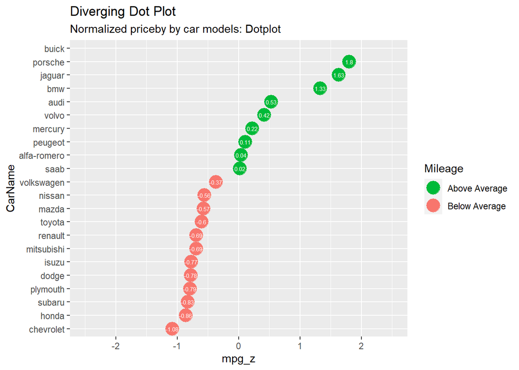

```r
grouped_sum_price <- train.data_for_eda %>% group_by(CarName) %>% summarise(sum_price=sum(price))
grouped_sum_price <- data.frame(grouped_sum_price)

grouped_cnt <- train.data_for_eda %>% group_by(CarName, .drop = FALSE) %>% count()
grouped_cnt <- data.frame(grouped_cnt)

data_above_below <- cbind(grouped_sum_price, grouped_cnt[2])

data_above_below$grouped_avg <- data_above_below$sum_price / data_above_below$n

data_above_below$mpg_z <- round((data_above_below$grouped_avg - mean(data_above_below$grouped_avg))/sd(data_above_below$grouped_avg), 2)  # compute normalized mpg
data_above_below$mpg_type <- ifelse(data_above_below$mpg_z < 0, "below", "above")  # above / below avg flag
data_above_below <- data_above_below[order(data_above_below$mpg_z), ]  # sort
data_above_below$CarName <- factor(data_above_below$CarName, levels = data_above_below$CarName)  # convert to factor to retain sorted order in plot.

ggplot(data_above_below, aes(x=CarName, y=mpg_z, label=mpg_z)) +
  geom_point(stat='identity', aes(col=mpg_type), size=6)  +
  scale_color_manual(name="Mileage",
                     labels = c("Above Average", "Below Average"),
                     values = c("above"="#00ba38", "below"="#f8766d")) +
  geom_text(color="white", size=2) +
  labs(title="Diverging Dot Plot",
       subtitle="Normalized priceby by car models: Dotplot") +
  ylim(-2.5, 2.5) +
  coord_flip()
```

**CATEGORICAL DATA ANALYSIS**

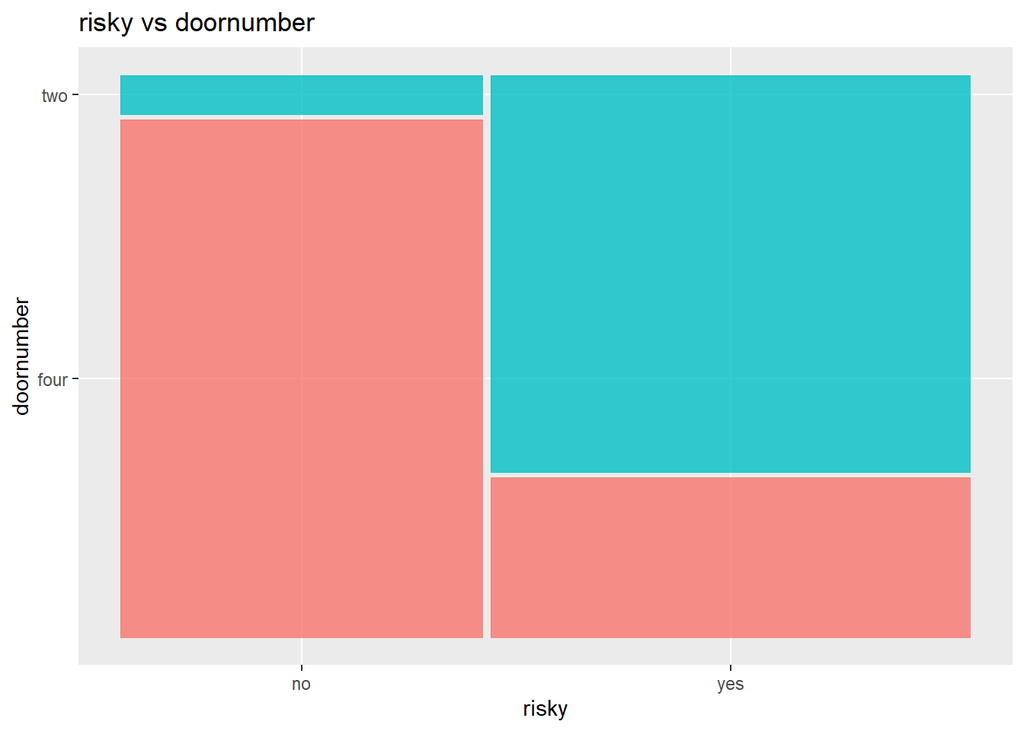

```r
ggplot(data=train.data_for_eda)+geom_mosaic(aes(x = product(doornumber, risky),fill=doornumber))+
  labs(x = "risky", y="doornumber",title='risky vs doornumber') + theme(legend.position = "none")
```

```r
or <- table(train.data_for_eda$doornumber, train.data_for_eda$risky)

epitools::riskratio(or,rev='both',method = 'wald')
```

```
## $data
##
##         yes no Total
##   two    67  5    72
##   four   27 66    93
##   Total  94 71   165
##
## $measure
##       risk ratio with 95% C.I.
##        estimate    lower    upper
##   two   1.00000       NA       NA
##   four 10.21935 4.344059 24.04093
##
## $p.value
##       two-sided
##        midp.exact fisher.exact   chi.square
##   two          NA           NA           NA
##   four          0 6.171204e-18 1.758685e-16
##
## $correction
## [1] FALSE
##
## attr(,"method")
## [1] "Unconditional MLE & normal approximation (Wald) CI"
```

**Yule’s Q**

Moreover, Yule’s Q value shows strong positive relation with door number and insurance risk (0.94).

```r
yules_q<-Yule(or)
yules_q
```

```
## [1] 0.9407505
```

**Chi-Square Statistics**

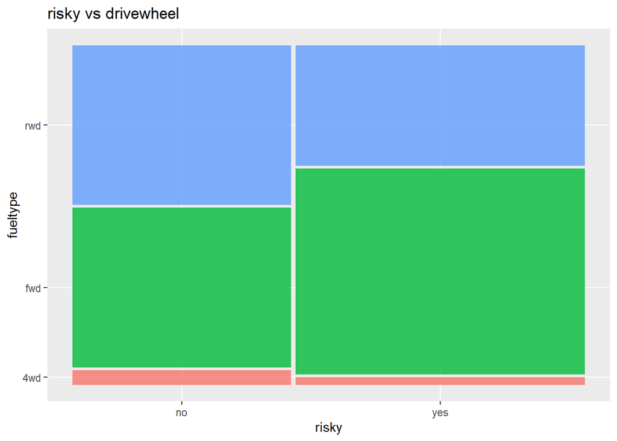

```r
ggplot(data=train.data_for_eda)+geom_mosaic(aes(x = product(drivewheel, risky),fill=drivewheel))+
  labs(x = "risky", y="fueltype",title='risky vs drivewheel') + theme(legend.position = "none")
```

```r
t2<-table(train.data_for_eda$drivewheel, train.data_for_eda$risky)
t2
```

```
##
##       no yes
##   4wd  3   2
##   fwd 34  58
##   rwd 34  34
```

```r
chisq.test(t2)
```

```
##
##  Pearson's Chi-squared test
##
## data:  t2
## X-squared = 3.3193, df = 2, p-value = 0.1902
```

**Cramer’s V**

Cramer’s V test also indicates no association between these two categories (0.14).

```r
assocstats(t2)
```

```
##                     X^2 df P(> X^2)
## Likelihood Ratio 3.3187  2  0.19026
## Pearson          3.3193  2  0.19021
##
## Phi-Coefficient   : NA
## Contingency Coeff.: 0.14
## Cramer's V        : 0.142
```

**Correlation Between a Continuous and Categorical Variable**

```r
ft <- c("wheelbase", "carlength", "carwidth", "carheight", "boreratio", "stroke",
        "compressionratio", "horsepower", "peakrpm", "citympg", "highwaympg")

for (i in ft) {
  bscor<- biserial.cor(train.data_for_eda[[i]], train.data_for_eda$risky)
  print(paste("for", i, "variable and risky, correlation is: ", bscor))
}
```

```
## [1] "for wheelbase variable and risky, correlation is:  0.499550269614029"
## [1] "for carlength variable and risky, correlation is:  0.43078741003115"
## [1] "for carwidth variable and risky, correlation is:  0.299579272664828"
## [1] "for carheight variable and risky, correlation is:  0.478018729504391"
## [1] "for boreratio variable and risky, correlation is:  0.278871979377882"
## [1] "for stroke variable and risky, correlation is:  0.0323331052679863"
## [1] "for compressionratio variable and risky, correlation is:  0.242879407659241"
## [1] "for horsepower variable and risky, correlation is:  0.0585474550632057"
## [1] "for peakrpm variable and risky, correlation is:  -0.245496410625985"
## [1] "for citympg variable and risky, correlation is:  -0.130650330592402"
## [1] "for highwaympg variable and risky, correlation is:  -0.16568658315015"
```

**FUTURE SELECTION**

Firstly, I will apply Ridge Regression. The aim is basically to find an optimal λ value which provides bias - variance balance. In this way, we can find the lowest potential MSE. Below “x” contains numerical variables without response (price).

```r
x=model.matrix (price ∼ .,train.data)[,-1]
```

“y” includes price.

```r
y=train.data$price
```

**Ridge Regression**

I will insert different values to λ ranging from 10^10 to 10^-2. Hence, we will have 100 different Ridge Regression coefficients.

```r
grid =10^ seq (10,-2, length =100)
ridge.mod =glmnet (x,y,alpha =0, lambda =grid)
```

```r
dim(coef(ridge.mod))
```

```
## [1]  73 100
```

One of these models is below:

```r
coef(ridge.mod)[,24]
```

```
##           (Intercept)   CarName.alfa.romero          CarName.audi
##          1.330859e+04          7.627070e-01          2.896256e+00
##           CarName.bmw         CarName.buick     CarName.chevrolet
##          6.340265e+00          1.150462e+01         -3.916562e+00
##         CarName.dodge         CarName.honda         CarName.isuzu
##         -2.731460e+00         -3.153531e+00         -2.655071e+00
##        CarName.jaguar         CarName.mazda       CarName.mercury
##          7.516860e+00         -1.891435e+00          1.530091e+00
##    CarName.mitsubishi        CarName.nissan       CarName.peugeot
##         -2.355836e+00         -1.893493e+00          1.100534e+00
##      CarName.plymouth       CarName.porsche       CarName.renault
##         -2.755009e+00          8.359747e+00         -2.300314e+00
##          CarName.saab        CarName.subaru        CarName.toyota
##          7.284649e-01         -2.946460e+00         -2.276750e+00
##    CarName.volkswagen         CarName.volvo       fueltype.diesel
##         -9.884951e-01          2.414694e+00          1.326850e+00
##          fueltype.gas        aspiration.std      aspiration.turbo
##         -1.326685e+00         -1.973375e+00          1.973129e+00
##       doornumber.four        doornumber.two   carbody.convertible
##          1.958827e-01         -1.958586e-01          7.512931e+00
##       carbody.hardtop     carbody.hatchback         carbody.sedan
##          2.537494e+00         -1.666811e+00          5.002161e-01
##         carbody.wagon        drivewheel.4wd        drivewheel.fwd
##          7.249225e-02         -2.272641e+00         -5.033443e+00
##        drivewheel.rwd             wheelbase             carlength
##          5.400023e+00          4.190162e-01          2.332074e-01
##              carwidth             carheight            curbweight
##          1.455047e+00          1.453911e-01          6.473828e-03
##       enginetype.dohc      enginetype.dohcv          enginetype.l
##          2.740412e+00          9.221348e+00          7.830710e-01
##        enginetype.ohc       enginetype.ohcf       enginetype.ohcv
##         -3.653594e+00         -1.084282e+00          6.714262e+00
##      enginetype.rotor  cylindernumber.eight   cylindernumber.five
##          3.728575e+00          1.262523e+01          4.362333e+00
##   cylindernumber.four    cylindernumber.six cylindernumber.twelve
##         -6.650509e+00          5.544497e+00          1.158952e+01
##    cylindernumber.two            enginesize       fuelsystem.1bbl
##         -1.098876e+00          8.099262e-02         -3.270174e+00
##       fuelsystem.2bbl       fuelsystem.4bbl        fuelsystem.idi
##         -4.274897e+00         -1.070987e+00          1.159714e+00
##        fuelsystem.mfi       fuelsystem.mpfi       fuelsystem.spdi
##         -2.902584e-01          4.411984e+00         -1.568159e+00
##       fuelsystem.spfi             boreratio                stroke
##         -1.279236e+00          9.186470e+00          3.083178e-01
##      compressionratio            horsepower               peakrpm
##          6.291559e-02          8.553944e-02         -8.392210e-04
##               citympg            highwaympg              risky.no
##         -4.577750e-01         -4.318450e-01          1.392903e+00
##             risky.yes
##         -1.392729e+00
```

In addition to tuning λ with 100 times, we will apply cross-validation, to find λ value where the model error is minimum.

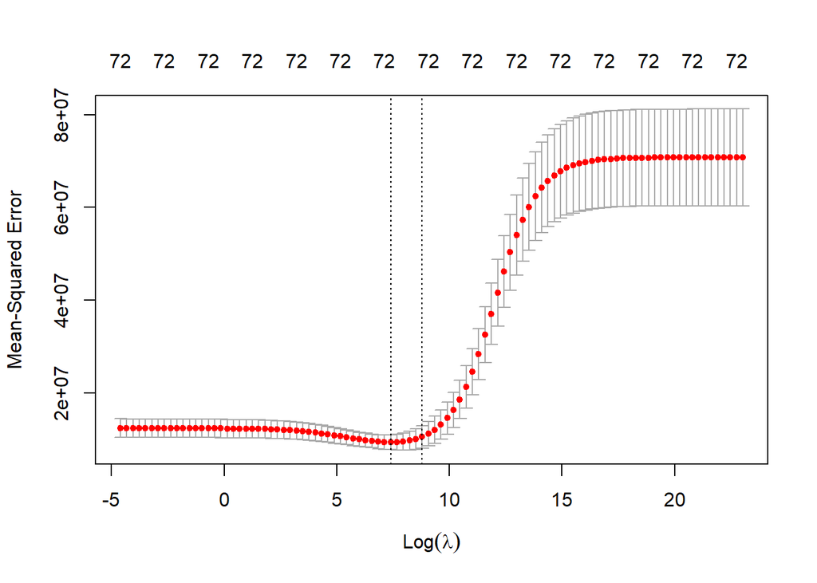

```r
set.seed(123)
cv_fit <- cv.glmnet(x, y, alpha = 0, lambda = grid)

opt_lambda <- cv_fit$lambda.min

plot(cv_fit)
```

Ridge Regression output:

```r
best_ridge <- glmnet(x, y, alpha = 0, lambda = opt_lambda) #best_ridge
coef(best_ridge)
```

```
## 73 x 1 sparse Matrix of class "dgCMatrix"
##                                  s0
## (Intercept)           -3.223591e+04
## CarName.alfa.romero   -7.631136e+02
## CarName.audi           1.858782e+03
## CarName.bmw            5.404249e+03
## CarName.buick          5.215681e+03
## CarName.chevrolet     -2.108188e+02
## CarName.dodge         -8.478264e+02
## CarName.honda         -2.022228e+02
## CarName.isuzu         -3.428432e+02
## CarName.jaguar         2.035044e+03
## CarName.mazda         -1.109864e+03
## CarName.mercury       -2.122423e+03
## CarName.mitsubishi    -1.401590e+03
## CarName.nissan        -1.346419e+03
## CarName.peugeot        4.491590e+02
## CarName.plymouth      -1.447585e+03
## CarName.porsche        5.572911e+03
## CarName.renault       -1.366593e+03
## CarName.saab           9.084035e+02
## CarName.subaru        -2.371201e+03
## CarName.toyota        -1.827568e+03
## CarName.volkswagen    -5.140071e+02
## CarName.volvo          2.269754e+02
## fueltype.diesel        1.239440e+02
## fueltype.gas          -1.208391e+02
## aspiration.std        -5.089205e+02
## aspiration.turbo       5.101847e+02
## doornumber.four       -4.978154e+01
## doornumber.two         5.012541e+01
## carbody.convertible    3.321868e+03
## carbody.hardtop        7.223651e+02
## carbody.hatchback      5.466556e+01
## carbody.sedan         -1.969808e+02
## carbody.wagon         -4.369499e+02
## drivewheel.4wd         2.298293e+02
## drivewheel.fwd        -5.788592e+02
## drivewheel.rwd         5.565208e+02
## wheelbase              7.623856e+01
```

[output cut: 20 more lines]

```
## fuelsystem.4bbl       -7.595335e+02
## fuelsystem.idi         2.947624e+02
## fuelsystem.mfi        -1.198680e+03
## fuelsystem.mpfi       -5.675913e+01
## fuelsystem.spdi       -6.678585e+02
## fuelsystem.spfi       -1.547167e+03
## boreratio              4.507657e+02
## stroke                -1.434864e+03
## compressionratio       2.243888e+01
## horsepower             3.103664e+01
## peakrpm                2.706556e-01
## citympg               -2.619368e+01
## highwaympg             8.967579e+00
## risky.no               1.349209e+02
## risky.yes             -1.328137e+02
```

Making prediction via best Ridge Regression:

```r
x_test <- model.matrix (price ∼ .,test.data)[,-1]
y_test <- test.data$price

ridge_prediction <- predict(best_ridge, s = opt_lambda, newx = x_test)
```

```r
sse_ridge <- MSE(ridge_prediction,test.data$price)
```

**LASSO Regression**

Using the same grid, in this time, I will apply LASSO Regression.

```r
lasso.mod =glmnet (x,y,alpha =1, lambda =grid)
```

Coefficient plot shows that only a few coefficients will be shrinked to zero at the end.

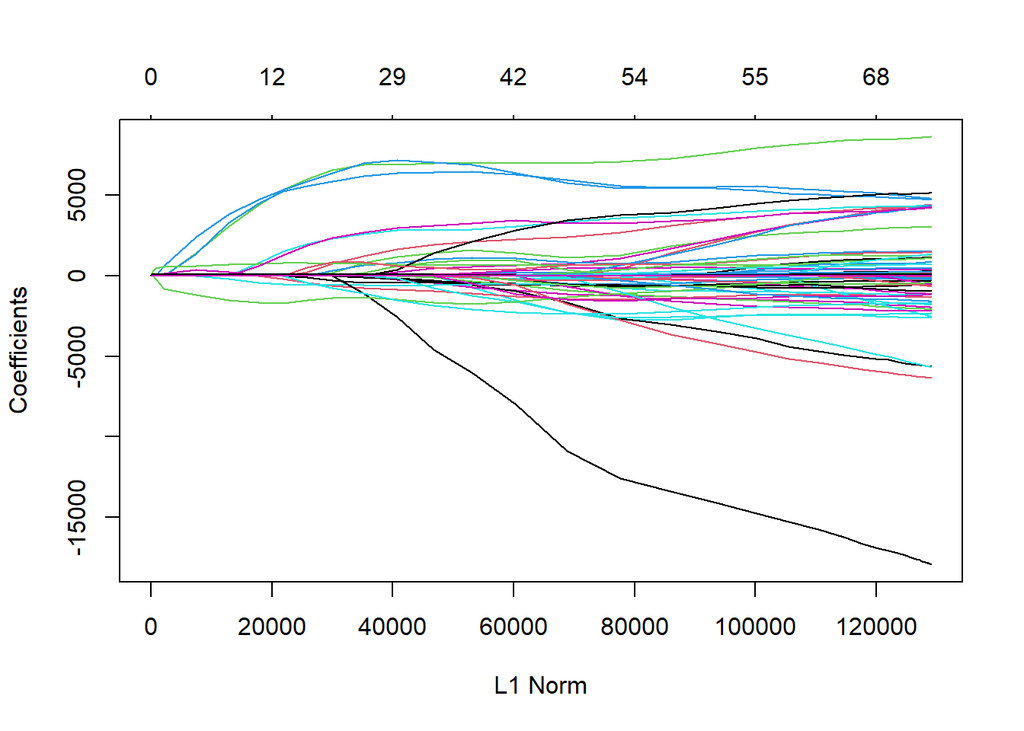

```r
plot(lasso.mod)
```

Again, by cross validation, we will try to find optimal λ.

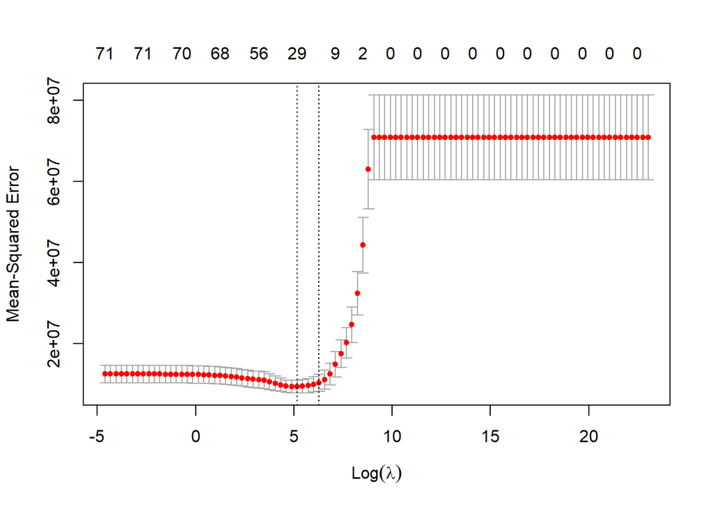

```r
set.seed(123)
cv.out =cv.glmnet (x,y,alpha =1, lambda =grid)

opt_lambda_lasso <- cv.out$lambda.min

plot(cv.out)
```

```r
best_lasso <- glmnet(x, y, alpha = 1, lambda = opt_lambda_lasso) #best_lasso

coef(best_lasso)
```

```
## 73 x 1 sparse Matrix of class "dgCMatrix"
##                                  s0
## (Intercept)           -4.287467e+04
## CarName.alfa.romero    .
## CarName.audi           1.642090e+03
## CarName.bmw            6.895821e+03
## CarName.buick          7.129503e+03
## CarName.chevrolet      .
## CarName.dodge          .
## CarName.honda          .
## CarName.isuzu          .
## CarName.jaguar         1.154767e+03
## CarName.mazda          .
## CarName.mercury        .
## CarName.mitsubishi    -2.347110e+02
## CarName.nissan        -4.554609e+02
## CarName.peugeot        .
## CarName.plymouth       .
## CarName.porsche        6.326264e+03
## CarName.renault        .
## CarName.saab           2.144341e+02
## CarName.subaru        -2.219386e+02
## CarName.toyota        -8.679391e+02
## CarName.volkswagen     .
## CarName.volvo          7.892032e+02
## fueltype.diesel        .
## fueltype.gas           .
## aspiration.std        -1.722267e+02
## aspiration.turbo       1.116863e-10
## doornumber.four        .
## doornumber.two         .
## carbody.convertible    2.792640e+03
## carbody.hardtop        .
## carbody.hatchback      .
## carbody.sedan          .
## carbody.wagon          .
## drivewheel.4wd         .
## drivewheel.fwd        -6.196744e+02
## drivewheel.rwd         .
## wheelbase              2.722780e+01
```

[output cut: 20 more lines]

```
## fuelsystem.4bbl        .
## fuelsystem.idi         .
## fuelsystem.mfi         .
## fuelsystem.mpfi        .
## fuelsystem.spdi        .
## fuelsystem.spfi        .
## boreratio              .
## stroke                -1.543576e+03
## compressionratio       3.441194e+01
## horsepower             3.532214e+01
## peakrpm                .
## citympg                .
## highwaympg             .
## risky.no               .
## risky.yes              .
```

Making prediction using best_lasso model:

```r
lasso_prediction <- predict(best_lasso, s = opt_lambda_lasso, newx = x_test)
```

```r
sse_lasso <- MSE(lasso_prediction,test.data$price)
sse_lasso
```

```
## [1] 2319013
```

**Elastic Regression**